### Part II

#### Solution

Tuesday, May 21, 2013

**5.** Consider the data below on the effects of a particular treatment for solid tumors patients from a double-blind clinical trial. The response is IMPROVEMENT measured by RECIST (Response Evaluation Criteria in Solid Tumors). RECIST is a set of published rules that define when cancer patients improve (“respond”), stay the same (“stabilize”), or worsen (“progression”) during treatments.

The data file `ob_prob5_solidtumor.txt` contains 84 observations and 5 variables. Age, gender, and treatment are the explanatory variables.

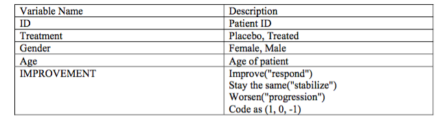

A snippet of the dataset is shown below:

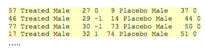

1. We are interested in estimating the respondent rate (the patients who have shown an improvement) for patients in each treatment group. Use a logistic regression to model the effect of treatment, gender and age on the respondent rate (assuming no interaction). Write down the fitted model.  
   **Solution**  
   Data manipulation:

```r
# Read in data
# Data is easy to read in SAS, but not in R.
# Steps:
# 1) Create 2 raw.text variables.
# 2) Read in data; skip header.
# 3) Split 1st data frame into two data frames.
# 4) Rename columns for all 3 data frames.
#    `rbind()` requires column names to be the same.
raw.text1 <- "
ID Treatment Gender Age Improved
57 Treated Male   27 0   9 Placebo Male   37 0
46 Treated Male   29 -1  14 Placebo Male   44 0
77 Treated Male   30 -1  73 Placebo Male   50 0
17 Treated Male   32 1  74 Placebo Male   51 0
36 Treated Male   46 1  25 Placebo Male   52 0
23 Treated Male   58 1  18 Placebo Male   53 0
75 Treated Male   59 -1  21 Placebo Male   59 0
39 Treated Male   59 1  52 Placebo Male   59 0
33 Treated Male   63 -1  45 Placebo Male   62 0
55 Treated Male   63 -1  41 Placebo Male   62 0
30 Treated Male   64 -1   8 Placebo Male   63 1
 5 Treated Male   64 0  80 Placebo Female 23 0
63 Treated Male   69 -1  12 Placebo Female 30 0
83 Treated Male   70 1  29 Placebo Female 30 0
66 Treated Female 23 -1  50 Placebo Female 31 1
40 Treated Female 32 -1  38 Placebo Female 32 0
 6 Treated Female 37 0  35 Placebo Female 33 1
 7 Treated Female 41 -1  51 Placebo Female 37 0
72 Treated Female 41 1  54 Placebo Female 44 0
37 Treated Female 48 -1  76 Placebo Female 45 0
82 Treated Female 48 1  16 Placebo Female 46 0
53 Treated Female 55 1  69 Placebo Female 48 0
79 Treated Female 55 1  31 Placebo Female 49 0
26 Treated Female 56 1  20 Placebo Female 51 0
28 Treated Female 57 1  68 Placebo Female 53 0
60 Treated Female 57 1  81 Placebo Female 54 0
22 Treated Female 57 1   4 Placebo Female 54 0
27 Treated Female 58 -1  78 Placebo Female 54 1
 1 Treated Female 59 1  70 Placebo Female 55 1
59 Treated Female 59 1  49 Placebo Female 57 0
62 Treated Female 60 1  10 Placebo Female 57 1
84 Treated Female 61 1  47 Placebo Female 58 1
64 Treated Female 62 0  44 Placebo Female 59 1
34 Treated Female 62 1  24 Placebo Female 59 1
58 Treated Female 66 1  48 Placebo Female 61 0
13 Treated Female 67 1  19 Placebo Female 63 1
61 Treated Female 68 0   3 Placebo Female 64 0
65 Treated Female 68 1  67 Placebo Female 65 1
11 Treated Female 69 -1  32 Placebo Female 66 0
56 Treated Female 69 0  42 Placebo Female 66 0
43 Treated Female 70 0  15 Placebo Female 66 1
"
raw.text2 <- "
                        71 Placebo Female 68 1
                         0 Placebo Female 74 1
"
tumor.raw1 <- read.table(header=FALSE, skip=2, text=raw.text1)
tumor.raw2 <- read.table(header=FALSE, text=raw.text2)

tumor.raw.A <- tumor.raw1[,1:5]
names(tumor.raw.A) <- c("ID", "Treatment", "Gender", "Age", "Improved")
tumor.raw.B <- tumor.raw1[,6:10]
names(tumor.raw.B) <- c("ID", "Treatment", "Gender", "Age", "Improved")
names(tumor.raw2) <- c("ID", "Treatment", "Gender", "Age", "Improved")

tumor.df <- rbind(tumor.raw.A, tumor.raw.B, tumor.raw2)


tumor.df$Improved <- factor(tumor.df$Improved)
tumor.df$Gender <- relevel(x=tumor.df$Gender, ref="Male")          # Changed to mirror the solution
tumor.df$Treatment <- relevel(x=tumor.df$Treatment, ref="Treated") # Changed to mirror the solution
```

Model:

```r
# Problem is concerned with binary outcome
tumor.df$yesORno <- ifelse(test=tumor.df$Improved==1, yes=1, no=0)
tumor.df$yesORno <- factor(tumor.df$yesORno)

tumor.logit <- glm(formula=yesORno ~ Treatment + Gender + Age, family=binomial(link="logit"), data=tumor.df)
summary(tumor.logit)
```

```
##
## Call:
## glm(formula = yesORno ~ Treatment + Gender + Age, family = binomial(link = "logit"),
##     data = tumor.df)
##
## Deviance Residuals:
##     Min       1Q   Median       3Q      Max
## -1.6672  -0.9852  -0.5524   0.9882   1.9601
##
## Coefficients:
##                  Estimate Std. Error z value Pr(>|z|)
## (Intercept)      -3.09636    1.26305  -2.451   0.0142 *
## TreatmentPlacebo -0.85293    0.48849  -1.746   0.0808 .
## GenderFemale      1.28203    0.56929   2.252   0.0243 *
## Age               0.04168    0.02035   2.048   0.0405 *
## ---
## Signif. codes:  0 '***' 0.001 '**' 0.01 '*' 0.05 '.' 0.1 ' ' 1
##
## (Dispersion parameter for binomial family taken to be 1)
##
##     Null deviance: 114.10  on 83  degrees of freedom
## Residual deviance: 100.63  on 80  degrees of freedom
## AIC: 108.63
##
## Number of Fisher Scoring iterations: 4
```

Model:
$$\text{Logit}(Improved=1) = \log \left(\frac{P(Y=1)}{1 - P(Y=1)}\right) = -3.09 - 0.85 x_{placebo} + 1.28 x_{gender} + 0.0417 \cdot age$$

```r
summary(tumor.logit)$coefficients
```

```
##                     Estimate Std. Error   z value   Pr(>|z|)
## (Intercept)      -3.09635743 1.26305127 -2.451490 0.01422662
## TreatmentPlacebo -0.85292714 0.48848641 -1.746061 0.08080033
## GenderFemale      1.28202761 0.56929207  2.251968 0.02432429
## Age               0.04168022 0.02034701  2.048469 0.04051407
```

Conclusion: “Reject $H_0$. Yes, in fact the odds of having an improvement (respondent for female is $e^{1.28} = 3.6$ times as of that for a male patient.”

3. For a specific age and gender, what is the estimated odds ratio of an improvement due to the treated treatment? Construct a 95% confidence interval for the odds ratio of improvement for receiving the treatment (holding age, gender constant).  
   **Solution**

```r
summary(tumor.logit)$coefficients
```

```
##                     Estimate Std. Error   z value   Pr(>|z|)
## (Intercept)      -3.09635743 1.26305127 -2.451490 0.01422662
## TreatmentPlacebo -0.85292714 0.48848641 -1.746061 0.08080033
## GenderFemale      1.28202761 0.56929207  2.251968 0.02432429
## Age               0.04168022 0.02034701  2.048469 0.04051407
```

```r
confint(tumor.logit)
```

```
##                         2.5 %      97.5 %
## (Intercept)      -5.787028153 -0.77430396
## TreatmentPlacebo -1.835490836  0.09191692
## GenderFemale      0.215152558  2.47381110
## Age               0.003661425  0.08446260
```

“Holding age and gender constant, the odds of having an improvement (respondent) for a patient on the treatment group is $e^{0.8529} = 2.35$ times that of a patient on a placebo group (or 1.35 times higher).  
”A 95% confidence interval for the odds ratio of improvement for receiving the treatment (holding age, gender constant): $(e^{-0.0919}, e^{1.8354}) = (0.91, 6.26)$."

4. For a given 62 year old female patient with placebo, what is the estimated probability of improvement?  
   **Solution**

```r
# predict.glm() can give fitted value for the log(P/(1-P)) value, or the probability itself
# log(P/(1-P))
predict.logit <- predict.glm(object=tumor.logit, newdata=data.frame(Treatment="Placebo", Gender="Female", Age=62), type="link", se.fit=TRUE)

# probability
predict.prob <- predict.glm(object=tumor.logit, newdata=data.frame(Treatment="Placebo", Gender="Female", Age=62), type="response", se.fit=TRUE)

# Using probability, the 95% confidence interval:
predict.prob$fit + c(- 1.96*predict.prob$se.fit, 1.96*predict.prob$se.fit)
```

```
##         1         1
## 0.2865215 0.6719605
```

Note: Output differs slightly from solution.  
Solution: “$P(Y=1| \text{62 y.o. female patient with placebo})= 0.46$ with a 95% CI from 0.28 to 0.65.”

5. Given that the response is measured by RECIST in three categories, can you name other model(s) you have learned might better apply for this case? Write down the **fitted** model.  
   **Solution**  
   Because there is more than two categories for the outcome (which are ordinal), a cumulative logit model would be applicable here.

```r
library(MASS)
tumor.polr <- polr(Improved ~ Treatment + Gender + Age, data=tumor.df)
summary(tumor.polr)
```

```
##
## Re-fitting to get Hessian
```

```
## Call:
## polr(formula = Improved ~ Treatment + Gender + Age, data = tumor.df)
##
## Coefficients:
##                    Value Std. Error t value
## TreatmentPlacebo 0.21963    0.43469  0.5053
## GenderFemale     1.17064    0.47528  2.4631
## Age              0.03916    0.01727  2.2682
##
## Intercepts:
##      Value  Std. Error t value
## -1|0 1.1547 1.0309     1.1201
## 0|1  3.4303 1.1000     3.1183
##
## Residual Deviance: 159.0847
## AIC: 169.0847
```

The fitted model:
$$\begin{align*}
\text{Logit(Improved = 1)} &= -3.43 + 0.220 x_{placebo} + 1.17 x_{female} + 0.0392 \cdot age \\
&\\
\text{Logit(Improved = 0)} &= -1.15 + 0.220 x_{placebo} + 1.17 x_{female} + 0.0392 \cdot age \\
&\\
\text{Logit(Improved = -1)} &= 0 + 0.220 x_{placebo} + 1.17 x_{female} + 0.0392 \cdot age
\end{align*}$$